# Spotify streams

## Top 100 Songs- Spotify Streams & Features Analysis

This data set is from kaggle: https://www.kaggle.com/datasets/amaanansari09/top-100-songs

**Questions:** 1) How many different artists made the top 100 list?

2) Who had the most amount of streams? Which songs are correlated with those artists?

3) Are there any normal distributions in the dataset? What does this say about those parameters?

```python
# import neccessary librarys
import numpy as np
import pandas as pd
import matplotlib.pyplot as plt
import seaborn as sns
from scipy.stats import skew
```

```python
# import data
features = pd.read_csv("../input/Features.csv")
streams = pd.read_csv("../input/Streams.csv")
```

### Begin exploratory data analysis

```python
features.info()
```

```
<class 'pandas.core.frame.DataFrame'>
RangeIndex: 100 entries, 0 to 99
Data columns (total 14 columns):
 #   Column            Non-Null Count  Dtype
---  ------            --------------  -----
 0   id                100 non-null    object
 1   name              100 non-null    object
 2   duration          100 non-null    float64
 3   energy            100 non-null    float64
 4   key               100 non-null    int64
 5   loudness          100 non-null    float64
 6   mode              100 non-null    int64
 7   speechiness       100 non-null    float64
 8   acousticness      100 non-null    float64
 9   instrumentalness  100 non-null    float64
 10  liveness          100 non-null    float64
 11  valence           100 non-null    float64
 12  tempo             100 non-null    float64
 13  danceability      100 non-null    float64
dtypes: float64(10), int64(2), object(2)
memory usage: 11.1+ KB
```

```python
streams.head()
```

|  | Song | Artist | Streams (Billions) | Release Date |
| --- | --- | --- | --- | --- |
| 0 | Blinding Lights | The Weeknd | 3.449 | 29-Nov-19 |
| 1 | Shape of You | Ed Sheeran | 3.398 | 06-Jan-17 |
| 2 | Dance Monkey | Tones And I | 2.770 | 10-May-19 |
| 3 | Someone You Loved | Lewis Capaldi | 2.680 | 08-Nov-18 |
| 4 | Rockstar | Post Malone featuring 21 Savage | 2.620 | 15-Sep-17 |

```python
streams.tail()
```

|  | Song | Artist | Streams (Billions) | Release Date |
| --- | --- | --- | --- | --- |
| 95 | 7 Years | Lukas Graham | 1.529 | 16-Jun-15 |
| 96 | Yellow | Coldplay | 1.527 | 26-Jun-00 |
| 97 | Sugar | Maroon 5 | 1.524 | 29-Aug-14 |
| 98 | Despacito | Luis Fonsi featuring Daddy Yankee | 1.522 | 12-Jan-17 |
| 99 | Don't Stop Me Now | Queen | 1.521 | 26-Jan-79 |

### 1) How many artists made the top 100 list?

```python
# using .nunique() will show how many different artists on the list
streams['Artist'].nunique()
```

```
81
```

#### Observations:

- There are 81 unique artists that made the top 100 list- this must mean that several artists have more than one top song on the list.

### 2a) Who had the most amount of streams?

```python
# This chart lists the artists with the most amout of streams
df1 = streams.groupby("Artist")['Streams (Billions)'].nunique().to_frame().reset_index().sort_values(by = 'Streams (Billions)', ascending = False)

df1
```

|  | Artist | Streams (Billions) |
| --- | --- | --- |
| 18 | Ed Sheeran | 4 |
| 80 | XXXTentacion | 3 |
| 27 | Imagine Dragons | 3 |
| 63 | Shawn Mendes | 3 |
| 33 | Justin Bieber | 2 |
| ... | ... | ... |
| 29 | James Arthur | 1 |
| 28 | J. Cole | 1 |
| 26 | Hozier | 1 |
| 24 | Halsey | 1 |
| 40 | Lil Uzi Vert | 1 |

81 rows × 2 columns

#### Observations:

- Ed Sheeran, XXX, Imagine Dragons and Shawn Mendes have the most amount of streams.

```python
# merge streams and features into one data frame
df_merge=pd.merge(left=streams, left_on="Song", right= features, right_on="name")

df_merge.info() # check .info() make sure everyhting is okay
```

```
<class 'pandas.core.frame.DataFrame'>
Int64Index: 100 entries, 0 to 99
Data columns (total 18 columns):
 #   Column              Non-Null Count  Dtype
---  ------              --------------  -----
 0   Song                100 non-null    object
 1   Artist              100 non-null    object
 2   Streams (Billions)  100 non-null    float64
 3   Release Date        100 non-null    object
 4   id                  100 non-null    object
 5   name                100 non-null    object
 6   duration            100 non-null    float64
 7   energy              100 non-null    float64
 8   key                 100 non-null    int64
 9   loudness            100 non-null    float64
 10  mode                100 non-null    int64
 11  speechiness         100 non-null    float64
 12  acousticness        100 non-null    float64
 13  instrumentalness    100 non-null    float64
 14  liveness            100 non-null    float64
 15  valence             100 non-null    float64
 16  tempo               100 non-null    float64
 17  danceability        100 non-null    float64
dtypes: float64(11), int64(2), object(5)
memory usage: 14.8+ KB
```

```python
# Find artists with more than one song using pivot table
dup = df_merge.pivot_table(index="Artist", aggfunc='size', sort=False)
print (dup)
```

```
Artist
The Weeknd                           2
Ed Sheeran                           4
Tones And I                          1
Lewis Capaldi                        1
Post Malone featuring 21 Savage      1
                                    ..
Jason Mraz                           1
Lauv                                 1
Lukas Graham                         1
Coldplay                             1
Luis Fonsi featuring Daddy Yankee    1
Length: 81, dtype: int64
```

```python
df_merge.loc[df_merge['Artist'] == 'The Weeknd']
```

|  | Song | Artist | Streams (Billions) | Release Date | id | name | duration | energy | key | loudness | mode | speechiness | acousticness | instrumentalness | liveness | valence | tempo | danceability |
| --- | --- | --- | --- | --- | --- | --- | --- | --- | --- | --- | --- | --- | --- | --- | --- | --- | --- | --- |
| 0 | Blinding Lights | The Weeknd | 3.449 | 29-Nov-19 | 0VjIjW4GlUZAMYd2vXMi3b | Blinding Lights | 3.33 | 0.730 | 1 | -5.934 | 1 | 0.0598 | 0.00146 | 0.000095 | 0.0897 | 0.334 | 171.005 | 0.514 |
| 47 | The Hills | The Weeknd | 1.802 | 27-May-15 | 7fBv7CLKzipRk6EC6TWHOB | The Hills | 4.04 | 0.564 | 0 | -7.063 | 0 | 0.0515 | 0.06710 | 0.000000 | 0.1350 | 0.137 | 113.003 | 0.585 |

```python
df_merge.loc[df_merge['Artist'] == 'Ed Sheeran']
```

|  | Song | Artist | Streams (Billions) | Release Date | id | name | duration | energy | key | loudness | mode | speechiness | acousticness | instrumentalness | liveness | valence | tempo | danceability |
| --- | --- | --- | --- | --- | --- | --- | --- | --- | --- | --- | --- | --- | --- | --- | --- | --- | --- | --- |
| 1 | Shape of You | Ed Sheeran | 3.398 | 06-Jan-17 | 7qiZfU4dY1lWllzX7mPBI3 | Shape of You | 3.90 | 0.652 | 1 | -3.183 | 0 | 0.0802 | 0.581 | 0.000000 | 0.0931 | 0.931 | 95.977 | 0.825 |
| 11 | Perfect | Ed Sheeran | 2.361 | 03-Mar-17 | 41P6Tnd8KIHqON0QIydx6a | Perfect | 2.96 | 0.663 | 11 | -6.818 | 1 | 0.0331 | 0.433 | 0.124000 | 0.1020 | 0.600 | 146.053 | 0.634 |
| 16 | Thinking Out Loud | Ed Sheeran | 2.177 | 20-Jun-14 | 0UduxLm2YxJcRMMX1K6E7E | Thinking Out Loud | 4.69 | 0.445 | 2 | -6.061 | 1 | 0.0296 | 0.474 | 0.000000 | 0.1840 | 0.591 | 78.997 | 0.781 |
| 22 | Photograph | Ed Sheeran | 2.099 | 20-Jun-14 | 4cj6Ti4wOXZ5ZdWlUZxRSP | Photograph | 4.32 | 0.379 | 4 | -10.480 | 1 | 0.0359 | 0.607 | 0.000472 | 0.0986 | 0.220 | 108.033 | 0.718 |

```python
df_merge.loc[df_merge['Artist'] == 'XXXTentacion']
```

|  | Song | Artist | Streams (Billions) | Release Date | id | name | duration | energy | key | loudness | mode | speechiness | acousticness | instrumentalness | liveness | valence | tempo | danceability |
| --- | --- | --- | --- | --- | --- | --- | --- | --- | --- | --- | --- | --- | --- | --- | --- | --- | --- | --- |
| 30 | Sad! | XXXTentacion | 1.987 | 01-Mar-18 | 3ee8Jmje8o58CHK66QrVC2 | Sad! | 2.78 | 0.613 | 8 | -4.880 | 1 | 0.1450 | 0.258 | 0.003720 | 0.123 | 0.473 | 75.023 | 0.740 |
| 36 | Jocelyn Flores | XXXTentacion | 1.905 | 31-Oct-17 | 7m9OqQk4RVRkw9JJdeAw96 | Jocelyn Flores | 1.99 | 0.391 | 0 | -9.144 | 0 | 0.2420 | 0.469 | 0.000004 | 0.297 | 0.437 | 134.021 | 0.872 |
| 82 | Moonlight | XXXTentacion | 1.600 | 16-Mar-18 | 0JP9xo3adEtGSdUEISiszL | Moonlight | 2.25 | 0.537 | 9 | -5.723 | 0 | 0.0804 | 0.556 | 0.004040 | 0.102 | 0.711 | 128.009 | 0.921 |

#### Observations:

- The Weeknd top two songs on this list are Blinding Lights and The Hills
- Ed Sheeran's top four songs are Shape of You, Perfect, Thinking Out Loud and Photograph
- XXX has three top songs: Sad!, Jocelyn Flores and Moonlight

### Next: Look at distributions of dataset

```python
# begin to look at stats info of the dataset
features.describe().T
```

|  | count | mean | std | min | 25% | 50% | 75% | max |
| --- | --- | --- | --- | --- | --- | --- | --- | --- |
| duration | 100.0 | 3.635300 | 0.807997 | 1.520000 | 3.12250 | 3.5050 | 4.030000 | 7.050 |
| energy | 100.0 | 0.625500 | 0.160045 | 0.185000 | 0.52375 | 0.6400 | 0.741000 | 0.912 |
| key | 100.0 | 5.340000 | 3.627114 | 0.000000 | 2.00000 | 6.0000 | 8.250000 | 11.000 |
| loudness | 100.0 | -6.176310 | 2.008580 | -12.205000 | -7.10375 | -5.9715 | -4.940750 | -2.810 |
| mode | 100.0 | 0.650000 | 0.479372 | 0.000000 | 0.00000 | 1.0000 | 1.000000 | 1.000 |
| speechiness | 100.0 | 0.096448 | 0.088872 | 0.028100 | 0.04120 | 0.0594 | 0.106000 | 0.438 |
| acousticness | 100.0 | 0.260955 | 0.272764 | 0.000025 | 0.02615 | 0.1625 | 0.431500 | 0.945 |
| instrumentalness | 100.0 | 0.007848 | 0.048977 | 0.000000 | 0.00000 | 0.0000 | 0.000086 | 0.459 |
| liveness | 100.0 | 0.165682 | 0.122867 | 0.034400 | 0.09430 | 0.1140 | 0.217000 | 0.790 |
| valence | 100.0 | 0.502032 | 0.224953 | 0.061200 | 0.34075 | 0.4920 | 0.663000 | 0.969 |
| tempo | 100.0 | 121.253900 | 29.544364 | 74.897000 | 98.02200 | 116.8640 | 142.439500 | 186.003 |
| danceability | 100.0 | 0.649630 | 0.144618 | 0.340000 | 0.54800 | 0.6715 | 0.759250 | 0.921 |

#### Observations:

- Loudness is the only feature in the negatives
- Energy, valence and duration seem to have the most normal distributions- will plot them all visually to confirm.
- Mode is an int() and a classification type because of its binary nature.

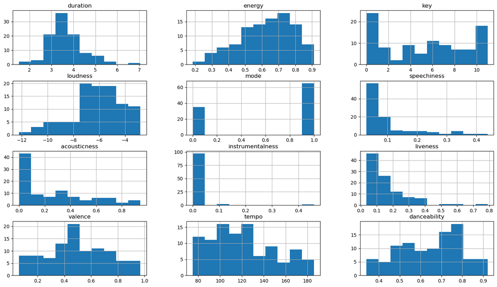

```python
fig, axes = plt.subplots(4, 3, figsize = (18, 10))
features.hist(ax = axes[0,0])
plt.show()
```

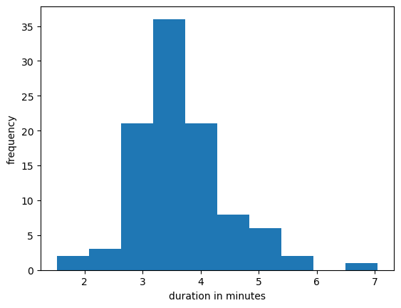

```
scew= 0.9129618365484795
```

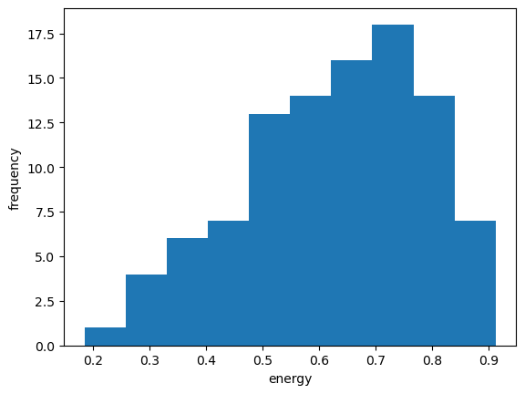

```
scew= -0.3914327605424058
```

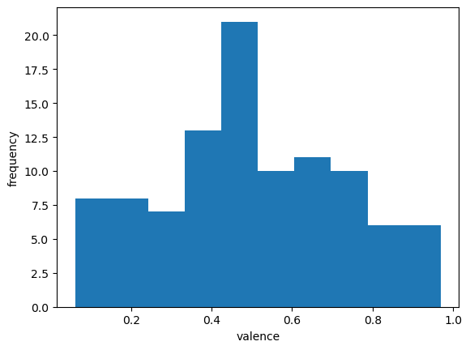

```
scew= 0.07057745136592954
```

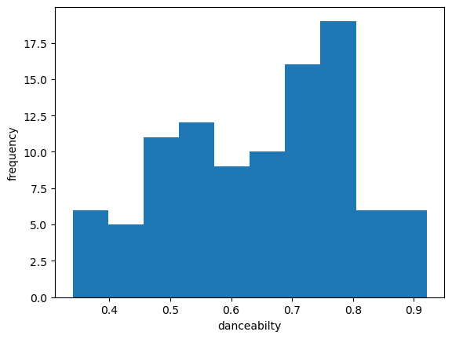

```
scew= -0.2728333483058009
```

```python
# These three elements have the closest graph to a normal curve

dur = features['duration']
plt.hist(dur)
plt.ylabel('frequency')
plt.xlabel('duration in minutes')
plt.show()
print('scew=', skew(dur, axis=0, bias=True))


print('*********************')

energy = features['energy']
plt.hist(energy)
plt.ylabel('frequency')
plt.xlabel('energy')
plt.show()
print('scew=',skew(energy, axis=0, bias=True))


print('*********************')

valence = features ['valence']
plt.hist(valence)
plt.ylabel('frequency')
plt.xlabel('valence')
plt.show()
print('scew=',skew(valence, axis=0, bias=True))


print('*********************')

dance = features ['danceability']
plt.hist(dance)
plt.ylabel('frequency')
plt.xlabel('danceabilty')
plt.show()
print('scew=',skew(dance, axis=0, bias=True))
```

#### Observations:

- Only duration, valence and energy have a normal shaped curve.
- All the graphs have a skew that falls within what is considered symmetric **except** for duration which is postively or right skewed. This means that the mean for duration is greater than its median and mode.
- For these features with normal distributions, there could be further analysis done such as kernel density estimation or Q-Q plots.